# sklearn.manifold.Isomap

**class*sklearn.manifold.Isomap(*, *n_neighbors=5*, *radius=None*, *n_components=2*, *eigen_solver='auto'*, *tol=0*, *max_iter=None*, *path_method='auto'*, *neighbors_algorithm='auto'*, *n_jobs=None*, *metric='minkowski'*, *p=2*, *metric_params=None*)[[source]](https://github.com/scikit-learn/scikit-learn/blob/f3f51f9b6/sklearn/manifold/_isomap.py#L22)**

Isomap Embedding.

Non-linear dimensionality reduction through Isometric Mapping

Read more in the User Guide.

**Parameters:**

**n_neighbors**int or None, default=5**

Number of neighbors to consider for each point. If `n_neighbors` is an int, then `radius` must be `None`.

**radius**float or None, default=None**

Limiting distance of neighbors to return. If `radius` is a float, then `n_neighbors` must be set to `None`.

New in version 1.1.

**n_components**int, default=2**

Number of coordinates for the manifold.

**eigen_solver**{‘auto’, ‘arpack’, ‘dense’}, default=’auto’**

‘auto’ : Attempt to choose the most efficient solver for the given problem.

‘arpack’ : Use Arnoldi decomposition to find the eigenvalues and eigenvectors.

‘dense’ : Use a direct solver (i.e. LAPACK) for the eigenvalue decomposition.

**tol**float, default=0**

Convergence tolerance passed to arpack or lobpcg. not used if eigen_solver == ‘dense’.

**max_iter**int, default=None**

Maximum number of iterations for the arpack solver. not used if eigen_solver == ‘dense’.

**path_method**{‘auto’, ‘FW’, ‘D’}, default=’auto’**

Method to use in finding shortest path.

‘auto’ : attempt to choose the best algorithm automatically.

‘FW’ : Floyd-Warshall algorithm.

‘D’ : Dijkstra’s algorithm.

**neighbors_algorithm**{‘auto’, ‘brute’, ‘kd_tree’, ‘ball_tree’}, default=’auto’**

Algorithm to use for nearest neighbors search, passed to neighbors.NearestNeighbors instance.

**n_jobs**int or None, default=None**

The number of parallel jobs to run. `None` means 1 unless in a [`joblib.parallel_backend`](https://joblib.readthedocs.io/en/latest/parallel.html#joblib.parallel_backend) context. `-1` means using all processors. See [Glossary](https://scikit-learn.org/1.1/glossary.html#term-n_jobs) for more details.

New in version 0.22.

**p**int, default=2**

Parameter for the Minkowski metric from sklearn.metrics.pairwise.pairwise_distances. When p = 1, this is equivalent to using manhattan_distance (l1), and euclidean_distance (l2) for p = 2. For arbitrary p, minkowski_distance (l_p) is used.

New in version 0.22.

**metric_params**dict, default=None**

Additional keyword arguments for the metric function.

New in version 0.22.

**Attributes:**

**embedding_**array-like, shape (n_samples, n_components)**

Stores the embedding vectors.

**kernel_pca_**object**

`KernelPCA` object used to implement the embedding.

**nbrs_**sklearn.neighbors.NearestNeighbors instance**

Stores nearest neighbors instance, including BallTree or KDtree if applicable.

**dist_matrix_**array-like, shape (n_samples, n_samples)**

Stores the geodesic distance matrix of training data.

**n_features_in_**int**

Number of features seen during fit.

New in version 0.24.

**feature_names_in_**ndarray of shape (`n_features_in_`,)**

Names of features seen during fit. Defined only when `X` has feature names that are all strings.

New in version 1.0.

See also

**`sklearn.decomposition.PCA`**

Principal component analysis that is a linear dimensionality reduction method.

**`sklearn.decomposition.KernelPCA`**

Non-linear dimensionality reduction using kernels and PCA.

**`MDS`**

Manifold learning using multidimensional scaling.

**`TSNE`**

T-distributed Stochastic Neighbor Embedding.

**`LocallyLinearEmbedding`**

Manifold learning using Locally Linear Embedding.

**`SpectralEmbedding`**

Spectral embedding for non-linear dimensionality.

#### References

[1]

Tenenbaum, J.B.; De Silva, V.; & Langford, J.C. A global geometric framework for nonlinear dimensionality reduction. Science 290 (5500)

#### Examples

```
>>> from sklearn.datasets import load_digits
>>> from sklearn.manifold import Isomap
>>> X, _ = load_digits(return_X_y=True)
>>> X.shape
(1797, 64)
>>> embedding = Isomap(n_components=2)
>>> X_transformed = embedding.fit_transform(X[:100])
>>> X_transformed.shape
(100, 2)
```

#### Methods

| `fit`(X[, y]) | Compute the embedding vectors for data X. |
| --- | --- |
| `fit_transform`(X[, y]) | Fit the model from data in X and transform X. |
| `get_feature_names_out`([input_features]) | Get output feature names for transformation. |
| `get_params`([deep]) | Get parameters for this estimator. |
| `reconstruction_error`() | Compute the reconstruction error for the embedding. |
| `set_params`(**params) | Set the parameters of this estimator. |
| `transform`(X) | Transform X. |

**fit(*X*, *y=None*)[[source]](https://github.com/scikit-learn/scikit-learn/blob/f3f51f9b6/sklearn/manifold/_isomap.py#L310)**

Compute the embedding vectors for data X.

**Parameters:**

**X**{array-like, sparse graph, BallTree, KDTree, NearestNeighbors}**

Sample data, shape = (n_samples, n_features), in the form of a numpy array, sparse graph, precomputed tree, or NearestNeighbors object.

**y**Ignored**

Not used, present for API consistency by convention.

**Returns:**

**self**object**

Returns a fitted instance of self.

**fit_transform(*X*, *y=None*)[[source]](https://github.com/scikit-learn/scikit-learn/blob/f3f51f9b6/sklearn/manifold/_isomap.py#L331)**

Fit the model from data in X and transform X.

**Parameters:**

**X**{array-like, sparse graph, BallTree, KDTree}**

Training vector, where `n_samples` is the number of samples and `n_features` is the number of features.

**y**Ignored**

Not used, present for API consistency by convention.

**Returns:**

**X_new**array-like, shape (n_samples, n_components)**

X transformed in the new space.

**get_feature_names_out(*input_features=None*)[[source]](https://github.com/scikit-learn/scikit-learn/blob/f3f51f9b6/sklearn/base.py#L909)**

Get output feature names for transformation.

**Parameters:**

**input_features**array-like of str or None, default=None**

Only used to validate feature names with the names seen in `fit`.

**Returns:**

**feature_names_out**ndarray of str objects**

Transformed feature names.

**get_params(*deep=True*)[[source]](https://github.com/scikit-learn/scikit-learn/blob/f3f51f9b6/sklearn/base.py#L194)**

Get parameters for this estimator.

**Parameters:**

**deep**bool, default=True**

If True, will return the parameters for this estimator and contained subobjects that are estimators.

**Returns:**

**params**dict**

Parameter names mapped to their values.

**reconstruction_error()[[source]](https://github.com/scikit-learn/scikit-learn/blob/f3f51f9b6/sklearn/manifold/_isomap.py#L285)**

Compute the reconstruction error for the embedding.

**Returns:**

**reconstruction_error**float**

Reconstruction error.

#### Notes

The cost function of an isomap embedding is

`E = frobenius_norm[K(D) - K(D_fit)] / n_samples`

Where D is the matrix of distances for the input data X, D_fit is the matrix of distances for the output embedding X_fit, and K is the isomap kernel:

`K(D) = -0.5 * (I - 1/n_samples) * D^2 * (I - 1/n_samples)`

**set_params(**params)[[source]](https://github.com/scikit-learn/scikit-learn/blob/f3f51f9b6/sklearn/base.py#L218)**

Set the parameters of this estimator.

The method works on simple estimators as well as on nested objects (such as `Pipeline`). The latter have parameters of the form `<component>__<parameter>` so that it’s possible to update each component of a nested object.

**Parameters:**

**paramsdict**

Estimator parameters.

**Returns:**

**self**estimator instance**

Estimator instance.

**transform(*X*)[[source]](https://github.com/scikit-learn/scikit-learn/blob/f3f51f9b6/sklearn/manifold/_isomap.py#L351)**

Transform X.

This is implemented by linking the points X into the graph of geodesic distances of the training data. First the `n_neighbors` nearest neighbors of X are found in the training data, and from these the shortest geodesic distances from each point in X to each point in the training data are computed in order to construct the kernel. The embedding of X is the projection of this kernel onto the embedding vectors of the training set.

**Parameters:**

**X**array-like, shape (n_queries, n_features)**

If neighbors_algorithm=’precomputed’, X is assumed to be a distance matrix or a sparse graph of shape (n_queries, n_samples_fit).

**Returns:**

**X_new**array-like, shape (n_queries, n_components)**

X transformed in the new space.

## Examples using `sklearn.manifold.Isomap`

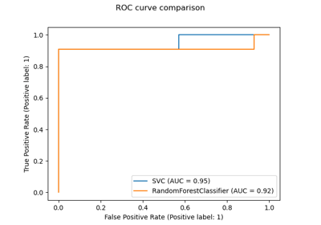

Release Highlights for scikit-learn 0.22

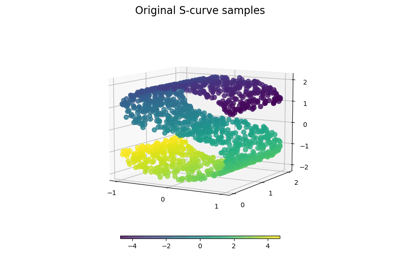

Comparison of Manifold Learning methods

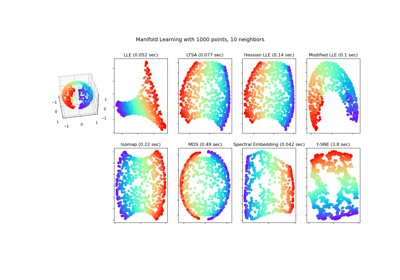

Manifold Learning methods on a severed sphere

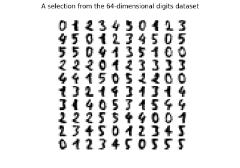

Manifold learning on handwritten digits: Locally Linear Embedding, Isomap…